# M5-Data Tidak Stasioner

Rafli Radithya

26/9/2023

# TUGAS M5 - DATA TIDAK STASIONER

## Tentang Data

Data yang digunakan merupakan data pertemuan 1 yaitu m4 data competition. Adapun data yang diambil pada peubah V2 sebanyak 300 data

## Package

```r
library(ggplot2)
library(tsibble)
library(tseries)
library(MASS)
```

## Input Data

```r
#Akses data
setwd("C:/Users/USER/OneDrive/Dokumen/PRAKTIKUM MPDW 2023/PRAKTIKUM MPDW 2023/pertemuan2/data")
mpdw=read.csv("mpdw2v2.csv",sep=";")
mpdw5=as.data.frame(mpdw)

#Diambil 300 data
mpdw5=mpdw[1:300,]
mpdw5
```

```
##            V2        V3        V4        V5
## 1    2039.200  2035.000  2051.800  2061.800
## 2    2986.000  3001.200  2975.900  2996.100
## 3    1120.700  1117.900  1115.100  1112.300
## 4    1190.000  1162.000  1134.000  1106.000
## 5    5904.670  5917.050  5922.580  5928.800
## 6    3182.052  3147.099  3143.850  3128.200
## 7    5860.008  7773.246  9477.872  8209.099
## 8    1732.200  1731.830  1739.170  1741.800
## 9    1584.410  1584.060  1590.770  1592.650
## 10   2618.000  2638.600  2648.700  2656.200
## 11   2440.200  2439.700  2469.300  2434.400
## 12   3663.300  3670.600  3704.100  3695.200
## 13   7208.400  7262.700  7251.200  7320.400
## 14   5762.900  5721.800  5789.500  5756.000
```

[output cut: 286 more lines]

## Eksplorasi Data

Plot Time Series dari data peubah V2 sebagai berikut

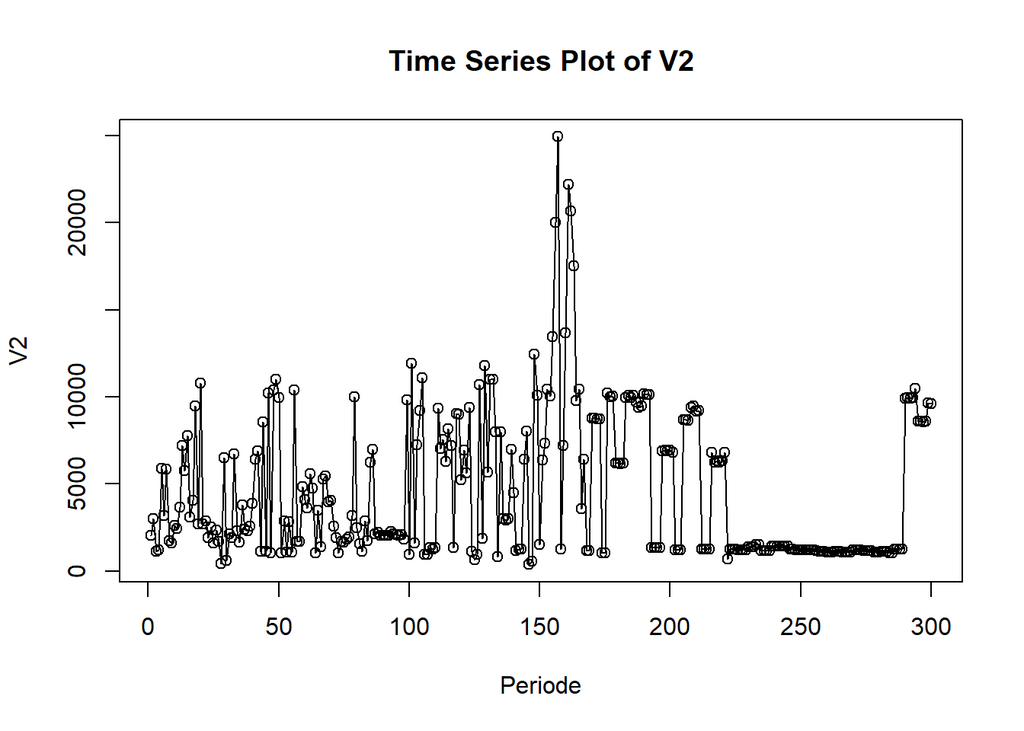

```r
#V2
v2.ts=ts(mpdw5$V2)
ts.plot(v2.ts, xlab="Periode", ylab="V2", main= "Time Series Plot of V2")
points(v2.ts)
```

Berdasarkan plot di atas, pola data cenderung bergerak di sekitar nilai tertentu dengan lebar pita pola data yang fluktuatif.

## Pengecekan Kestasioneran Data V2

1. Plot ACF

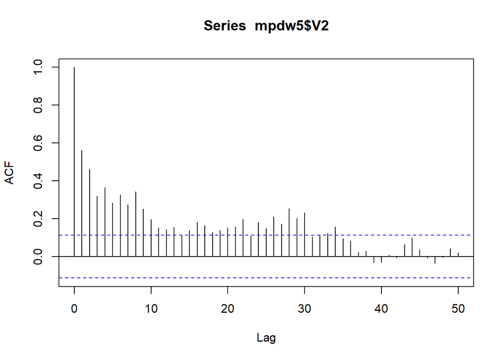

   ```r
   #Plot ACF
   acf(mpdw5$V2,lag.max=50)
   ```

   Berdasarkan plot ACF, pola data terlihat tails off slowly. Data mulai memasuki rentang pada lag 35 sehingga diduga bahwa pola data V2 tidak stasioner dalam rataan
2. Stasioner dalam rataan

   Pengujian formal kestasioneran data menurut rataan dengan metode Augmented Dickey-Fuller Test. Adapun hipotesisnya sebagai berikut

   $H_0$ : Data Tidak Stasioner

   $H_1$ : Data Stasioner

   ```r
   #ADF test
   tseries::adf.test(mpdw5$V2)
   ```

   ```
   ##
   ##  Augmented Dickey-Fuller Test
   ##
   ## data:  mpdw5$V2
   ## Dickey-Fuller = -3.3854, Lag order = 6, p-value = 0.05716
   ## alternative hypothesis: stationary
   ```

   Berdasarkan nilai P- Value dari Augmented Dickey-Fuller Test, didapatkan $p-value>a_{0.05}$ sehingga belum cukup bukti untuk menolak $H_0$ yang berarti data tidak stasioner
3. Stasioner dalam ragam

   Kestasioneran data menurut ragam, dapat dilihat secara eksplorasi dengan plot box-cox sebagai berikut

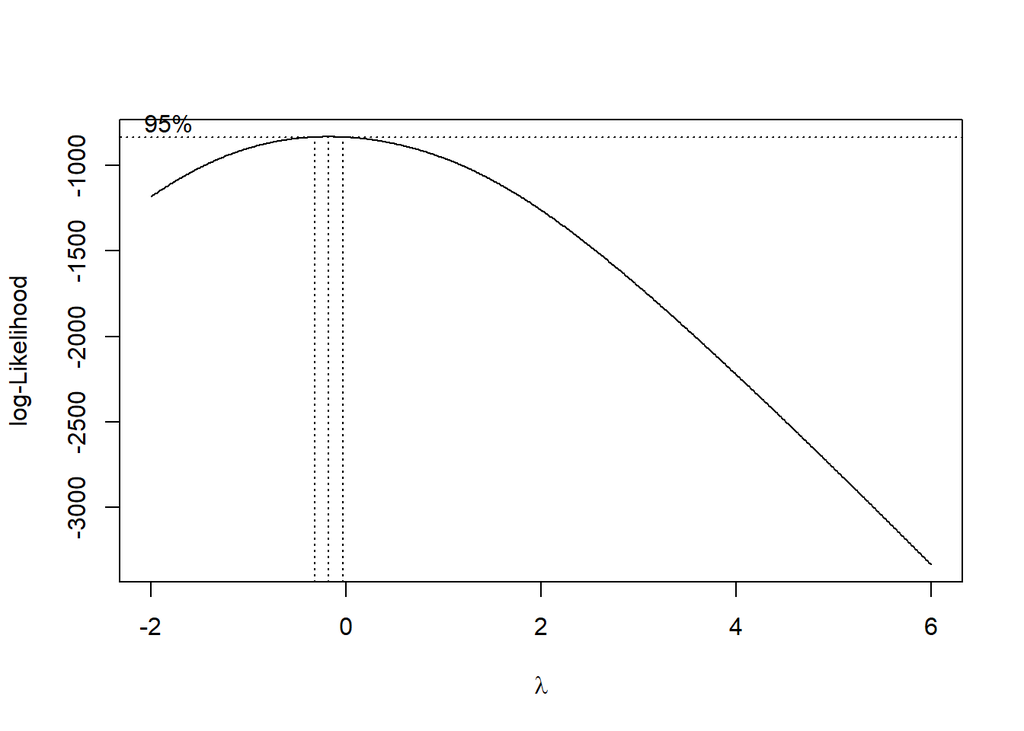

   ```r
   #Box-Cox Plot
   index <- seq(1:300)
   bc = boxcox(mpdw5$V2~index, lambda = seq(-2,6,by=0.01))
   ```

   ```r
   #Nilai Rounded Lambda
   lambda <- bc$x[which.max(bc$y)]
   lambda
   ```

   ```
   ## [1] -0.18
   ```

   ```r
   #SK
   bc$x[bc$y > max(bc$y) - 1/2 * qchisq(.95,1)]
   ```

   ```
   ##  [1] -0.32 -0.31 -0.30 -0.29 -0.28 -0.27 -0.26 -0.25 -0.24 -0.23 -0.22 -0.21
   ## [13] -0.20 -0.19 -0.18 -0.17 -0.16 -0.15 -0.14 -0.13 -0.12 -0.11 -0.10 -0.09
   ## [25] -0.08 -0.07 -0.06 -0.05 -0.04
   ```

   Berdasarkan plot box-cox, didapatkan bahwa nilai $\lambda$ optimumnya sebesar -0.18. Adapun Selang Kepercayaan 95% di antara -0.32 dan -0.04 yang berarti tidak memuat nilai 1 sehingga data tidak stasioner dalam ragam

## Pengecekan Kestasioneran Data Partisi 1 V2

Data V2 akan dipartisi hingga data ke-90 saja yang selanjutnya akan dicek kestasionerannya

1. Plot TS

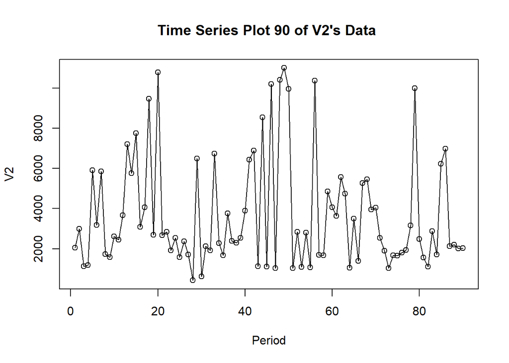

   ```r
   #Partisi data
   mpdw6=mpdw5[1:90,1]

   #Plot TS
   v3.ts=ts(mpdw6)
   ts.plot(v3.ts, xlab="Period", ylab="V2", main= "Time Series Plot 90 of V2's Data ")
   points(v3.ts)
   ```

   Berdasarkan plot di atas, pola data cenderung bergerak di sekitar nilai tertentu dengan lebar pita pola data yang fluktuatif.
2. Plot ACF

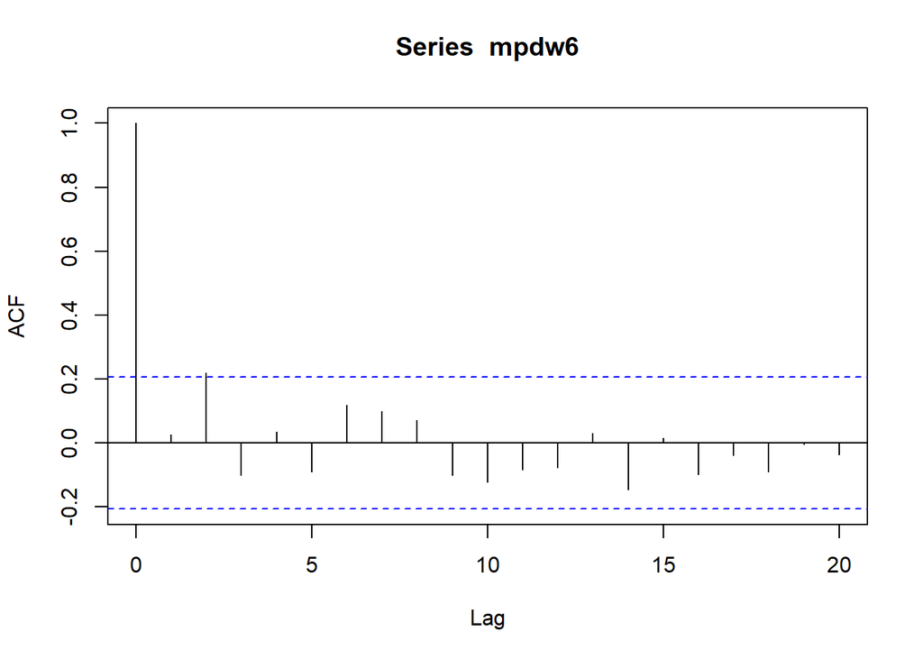

   ```r
   #Plot ACF
   acf(mpdw6,lag.max=20)
   ```

   Berdasarkan plot ACF, terlihat bahwa data berpola tail-off secara cepat sehingga dapat diduga bahwa data stasioner
3. Stasioner dalam rataan

   Pengujian formal kestasioneran data menurut rataan dengan metode Augmented Dickey-Fuller Test. Adapun hipotesisnya sebagai berikut

   $H_0$ : Data Tidak Stasioner dalam rataan

   $H_1$ : Data Stasioner

   ```r
   #ADF test
   tseries::adf.test(mpdw6)
   ```

   ```
   ##
   ##  Augmented Dickey-Fuller Test
   ##
   ## data:  mpdw6
   ## Dickey-Fuller = -4.0881, Lag order = 4, p-value = 0.01
   ## alternative hypothesis: stationary
   ```

   Berdasarkan nilai P- Value dari Augmented Dickey-Fuller Test, didapatkan $p-value<a_{0.05}$ sehingga cukup bukti untuk menolak $H_0$ yang berarti data stasioner menurut rataan
4. Plot Box-Cox

   Kestasioneran data menurut ragam, dapat dilihat secara eksplorasi dengan plot box-cox sebagai berikut

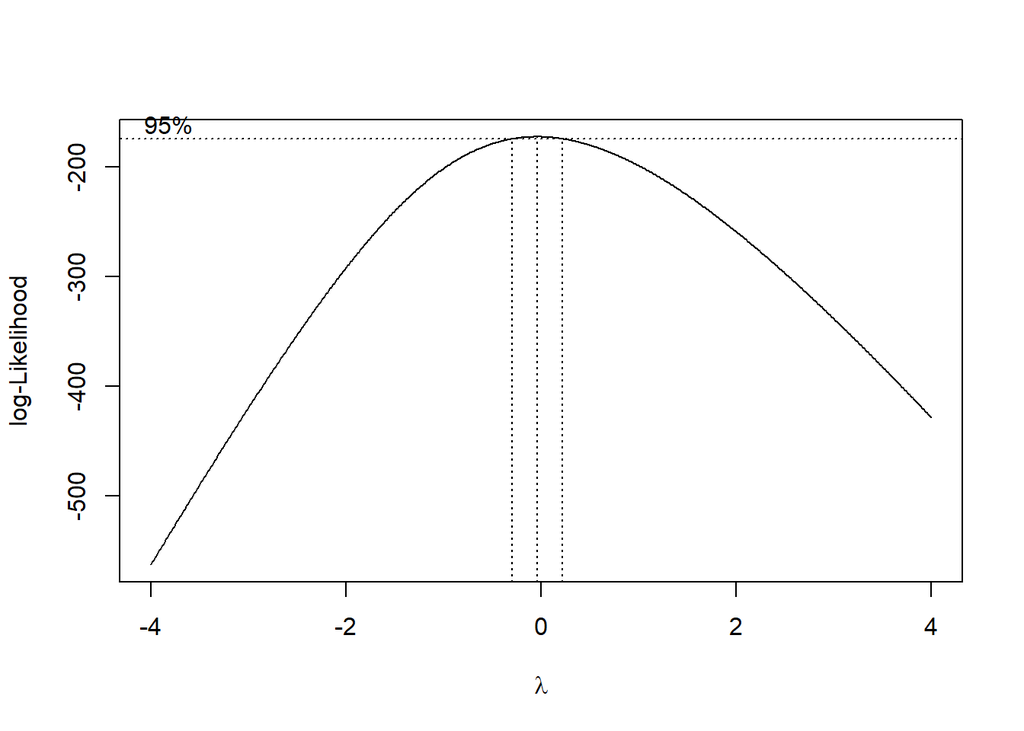

   ```r
   #Box-Cox Plot
   index <- seq(1:90)
   bc = boxcox(mpdw6~index, lambda = seq(-4,4,by=0.01))
   ```

   ```r
   #Nilai Rounded Lambda
   lambda <- bc$x[which.max(bc$y)]
   lambda
   ```

   ```
   ## [1] -0.04
   ```

   ```r
   #SK
   bc$x[bc$y > max(bc$y) - 1/2 * qchisq(.95,1)]
   ```

   ```
   ##  [1] -0.29 -0.28 -0.27 -0.26 -0.25 -0.24 -0.23 -0.22 -0.21 -0.20 -0.19 -0.18
   ## [13] -0.17 -0.16 -0.15 -0.14 -0.13 -0.12 -0.11 -0.10 -0.09 -0.08 -0.07 -0.06
   ## [25] -0.05 -0.04 -0.03 -0.02 -0.01  0.00  0.01  0.02  0.03  0.04  0.05  0.06
   ## [37]  0.07  0.08  0.09  0.10  0.11  0.12  0.13  0.14  0.15  0.16  0.17  0.18
   ## [49]  0.19  0.20  0.21  0.22
   ```

   Berdasarkan plot box-cox, didapatkan bahwa nilai $\lambda$ optimumnya sebesar -0.04. Adapun Selang Kepercayaan 95% di antara -0.29 dan 0.22 yang berarti tidak memuat nilai 1 sehingga data tidak stasioner menurut ragam

## Pengecekan Kestasioneran Data Partisi 2 V2

Data V2 akan dipartisi hingga data ke-230 saja yang selanjutnya akan dicek kestasionerannya

1. Plot TS

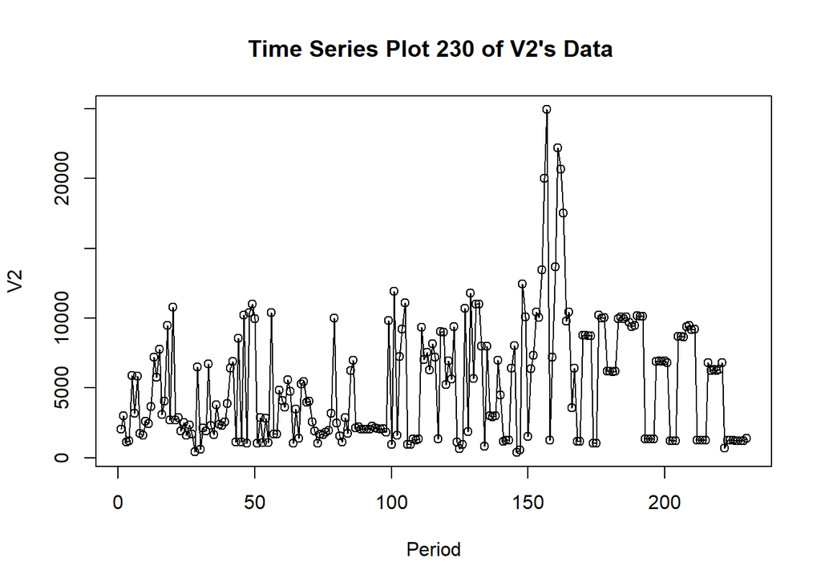

   ```r
   #Partisi data
   mpdw7=mpdw5[1:230,1]

   #Plot TS
   v3.ts=ts(mpdw7)
   ts.plot(v3.ts, xlab="Period", ylab="V2", main= "Time Series Plot 230 of V2's Data ")
   points(v3.ts)
   ```

   Berdasarkan plot di atas, pola data cenderung bergerak di sekitar nilai tertentu dengan lebar pita pola data yang fluktuatif.
2. Plot ACF

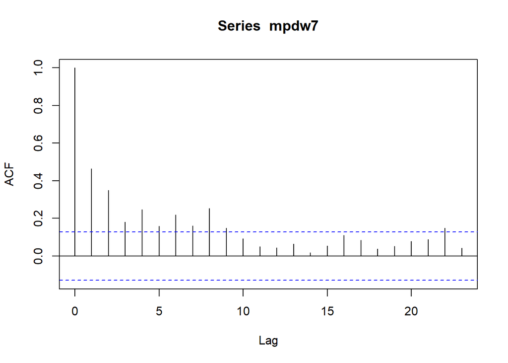

   ```r
   acf(mpdw7)
   ```

   Pengujian formal kestasioneran data menurut rataan dengan metode Augmented Dickey-Fuller Test. Adapun hipotesisnya sebagai berikut

   $H_0$ : Data Tidak Stasioner dalam rataan

   $H_1$ : Data Stasioner dalam rataan

   ```r
   #ADF test
   tseries::adf.test(mpdw7)
   ```

   ```
   ##
   ##  Augmented Dickey-Fuller Test
   ##
   ## data:  mpdw7
   ## Dickey-Fuller = -3.6806, Lag order = 6, p-value = 0.02643
   ## alternative hypothesis: stationary
   ```

   Berdasarkan nilai P- Value dari Augmented Dickey-Fuller Test, didapatkan $p-value<a_{0.05}$ sehingga cukup bukti untuk menolak $H_0$ yang berarti data stasioner menurut rataan
4. Kestasioneran dalam ragam

   Kestasioneran dalam ragam dapat dilihat dengan plot box-cox sebagai berikut

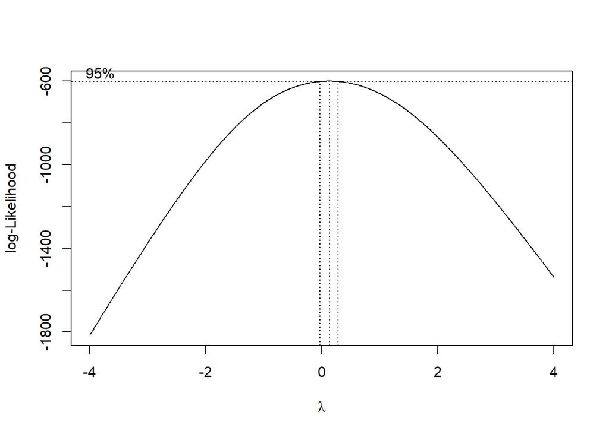

   ```r
   #Box-Cox Plot
   index <- seq(1:230)
   bc = boxcox(mpdw7~index, lambda = seq(-4,4,by=0.01))
   ```

   ```r
   #Nilai Rounded Lambda
   lambda <- bc$x[which.max(bc$y)]
   lambda
   ```

   ```
   ## [1] 0.13
   ```

   ```r
   #SK
   bc$x[bc$y > max(bc$y) - 1/2 * qchisq(.95,1)]
   ```

   ```
   ##  [1] -0.03 -0.02 -0.01  0.00  0.01  0.02  0.03  0.04  0.05  0.06  0.07  0.08
   ## [13]  0.09  0.10  0.11  0.12  0.13  0.14  0.15  0.16  0.17  0.18  0.19  0.20
   ## [25]  0.21  0.22  0.23  0.24  0.25  0.26  0.27  0.28
   ```

   Berdasarkan plot box-cox, didapatkan bahwa nilai $\lambda$ optimumnya sebesar 0.13. Adapun Selang Kepercayaan 95% di antara -0.03 dan 0.28 yang berarti tidak memuat nilai 1 sehingga data tidak stasioner menurut ragam

## Kesimpulan

Berdasarkan pengecekan kestasioneran data V2, didapatkan beberapa kesimpulan, yaitu

1. Data V2 tidak stasioner baik menurut ragam, maupun rataannya
2. Data partisi V2 yang merupakan data periode 1 hingga 90 menunjukan stasioner menurut rataan, tetapi tidak dengan ragam
3. Data partisi V2 yang merupakan data periode 1 hingga 230 menunjukan stasioner menurut rataan, tetapi tidak dengan ragam